# Hidden Markov Model

Cheetah 1 Movement Behavior Estimation

Farid Cheraghi

2023-10-28

# 1 Intro

We have used the hidden Markov chain to estimate the probability of the animal being in each state. Hidden Markov chain is also helpful when we include covariates. Incorporating covariates, if there is any correlation with the movement metrics (step-length and turn-angle), improves the model fitting and behavioral estimation; it also provides us with the transitional probability matrices per covariate.

# 2 Movement metrics

# 3 Model fitting

Wind direction is the only circular covariate in the list of our covariates. Circular statistics generally don’t have magnitude, i.e. wind direction of 350 degree, is not much different from wind direction of 10 degree. In order to introduce magnitude to wind direction, we have used cosine of wind direction instead. Cosine or Sine, take the periodicity of the statistics into account and therefore `cos(350)` is very close to `cos(10)`. However the cosine of 90 degree is not different from cosine 270, thus we have also computed the sine of the wind direction and added it as covariate.

Wind direction is reported by meteorological organizations by the direction from which it originates. For example, a northerly wind blows from the north to the south. Wind direction is usually reported in cardinal directions or in azimuth degrees. For example, a wind coming from the south is given as 180 degrees; one from the east is 90 degrees.

## 3.1 Initial parameters

In the rest of this document, state 1 and resting state, state 2 and moving state are used interchangeably.

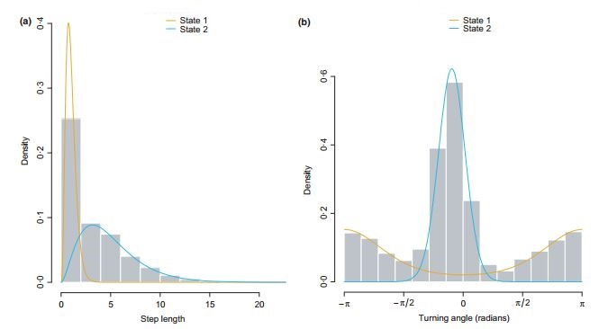

step-length and turn-angle distribution in high contrast situation

### 3.1.1 Step-length

The mean-variance parameterization is being used for gamma instead of more common shape-rate parameterization as it is more intuitive to reason about and relate to the step-length. A good practice to choose the initial mean and variance for the gamma distribution is to plot the step-length histogram and then overlay the density of gamma distribution using various mean and variance values to make it as close as possible to the gamma density shown in the above image. With the case of cheetah step-length, after a few trial and error, I found the following values as the best initial values for step-length gamma distribution:

Initial values chosen for gamma distribution of cheetah step-length

|  | Mean | Standard deviation |
| --- | --- | --- |
| State 1 | 0.1 | 0.1 |
| State 2 | 0.5 | 0.3 |

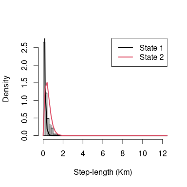

Superimposition of gamma density function on step-length histogram with various mean and standard deviation values to choose initial values

```r
# invisible(futils::par_fav())
# load ch1 windspeed hmm model
load('main.rda')
source('helpers.r')
hist(
  ch1_hmm_windspeed$data$step,
  freq = F,
  col = "gray",
  xlab = 'Step-length (Km)',
  xlim = c(0, 12),
  #ylim= c(0,1),
  main = "")

curve(moveHMM:::dgamma_rcpp(x,.1,.1),0,20,col=1,add=T,lwd=2) #state 1
curve(moveHMM:::dgamma_rcpp(x,.5,.3),0,20,col=2,add=T,lwd=2) #state 2
legend("topright",legend=c("State 1","State 2"),lwd=2,col=1:2)
```

It is also better to introduce variation to the initial values. Due to the numerical instability, in the model selection procedure, one fixed initial value may not work and the model fitting won’t converge. We have introduced random variation using normal distribution with a relatively small variance (0.1) to the initial values to overcome this situation.

```r
mu0 <- c(rnorm(1,.1,sd=.1),rnorm(1,.5,sd = .1))    #initial mu of State 1, State 2
sigma0 <- c(rnorm(1,.1, sd=.1),rnorm(1,.3, sd=.1)) #initial sigma of State 1, State 2
```

If some steps are exactly equal to zero, then strictly positive distributions such as the gamma are inadequate. In such cases, zero-inflated distributions can be considered. A zero-inflated step length distribution simply assumes that there is a probability z of observing a 0 and a probability of (1−z) of observing a positive value distributed according to a standard positive distribution (e.g. a gamma). In that case the (state-dependent) values z will be estimated, with the remaining positive distribution, weighted by (1−z), specified as one of the available standard step length distributions (Patterson et al. 2009; Langrock et al. 2012). We have excluded the zero-step length before model fitting and therefore set the *zero mass* equal to 0.

### 3.1.2 Turn-angle

Model fitting convergence is not very much sensitive to the turn-angle initial values compared to step-length. Turn-angle means are set to zero and kept fixed for both states and only concentration ($\kappa$) parameter of Von Mises is being estimated where the initial values are set to 1 for moving state and set to a value near zero (0.1) for resting state.

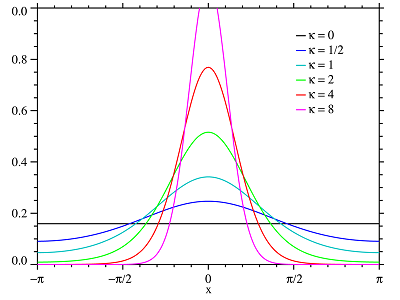

Von-mises distribution for various concentration values

## 3.2 Additional terms

We have computed additional terms to undertake a thorough model selection procedure. Individual covariates (12) along with their square root , logarithm, cosine of angle variables (“wind direction”) and 2nd order polynomials are added as additional covariates. All possible interactions of the main effects are also used in the model fitting process. To avoid further complexity, we have assumed the relation is linear and additive. For example, we have models of this type:

$${\beta _0} + {\beta _1}\cos
(wind\_direction) + {\beta _2}height + {\beta _3}heigh{t^2} + {\beta
_5}temperature . elevation$$

List of additional covariates computed from main effects

| Main Effects | Square Root | Logarithm | Angle Cosine | Polynomials | Interaction | Sum |
| --- | --- | --- | --- | --- | --- | --- |
| 12 | 12 | 12 | 2 | 24 | 12 | 74 |

So we have 74 covariates that we have to build our model on. Definitely, the best automatic approach would be “best subset selection” that takes every possible combination of covariates and compares the models performance, i.e. using AIC values. However, for $n=74$, $2^n = 1.9 \times {10^{22}}$ models will be computed which is not reasonable. Instead we have opted for the “forward step wise selection” which will not find the best possible model, rather a parsimonious model close to the best model. forward step wise selection procedure reduces the number of models to be evaluated to about $n^2 = 5476$, which can be done using a modern computer in a fair amount of time.

## 3.3 Forward step-wise selection

We have implemented the “forward step wise selection” to select the best set of covariates. The pseudo-code is as the following algorithm:

| Forward step wise selection (FSWS) algorithm (James et al. 2013) |
| --- |
| 1. Let $M_0$ denote the null model, which contains no predictors. |
| 2. For $k=0,...,p-1$: |
| i) Consider all $p-k$ models that augment the predictors in $M_k$ with one additional predictor. |
| ii) Choose the best among these $p-k$ models, and call it $M_{k+1}$. |
| Here best is defined as having highest likelihood (MLE) value. |
| 3. Select a single best model from among $M_0,...,M_p AIC$. |

## 3.4 Result

The result of FSWS leads to a few models that outperform the null model. The best model, in terms of AIC values, is the model with `~wind_speed + city_dist` covariates. The `~1` is the null model without any covariate in the following table. The third column in this table is the agreement of the states estimated using Viterbi algorithm against the null model states estimation.

AIC values of models that outperform null model

| Name | AIC | State-agreement |
| --- | --- | --- |
| ~wind_speed+city_dist | 980.56 | 0.93 |
| ~wind_speed | 981.41 | 0.97 |
| ~wind_speed+elevation+city_dist | 981.79 | 0.92 |
| ~wind_speed+elevation | 982.89 | 0.97 |
| ~1 | 986.64 | 1.00 |

## 3.5 Goodness of fit

```r
# jarque bera test for noramlity of step-length and turn-angle pseudo residuals
ch1_hmm_windspeed %>%
moveHMM::pseudoRes() %$%
  list(
    step = tseries::jarque.bera.test(stepRes[complete.cases(stepRes)]),
    angleRes = tseries::jarque.bera.test(angleRes[complete.cases(angleRes)])
  )
```

```
## $step
##
##  Jarque Bera Test
##
## data:  stepRes[complete.cases(stepRes)]
## X-squared = 5.8747, df = 2, p-value = 0.05301
##
##
## $angleRes
##
##  Jarque Bera Test
##
## data:  angleRes[complete.cases(angleRes)]
## X-squared = 1.4284, df = 2, p-value = 0.4896
```

```
## Computing pseudo-residuals... DONE
```

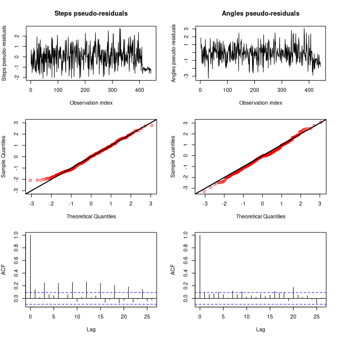

Time series, qq-plots, and autocorrelation functions of the pseudo-residuals of the 2-states model.

```r
moveHMM::plotPR(ch1_hmm_windspeed)
```

## 3.6 Coeficient 95% Confidence Intervals

The 95% confidence interval of the coefficients shows that the effect of wind speed is only significant in the transitions from state 1 to state 2 or 1. The coefficients are estimated only for **1 > 2** and **2 > 1**. The coefficients for **1 > 1** could be computed from the coefficients of **1 > 2** and the coefficients for **2 > 2** could be computed from coefficients of **2 > 1**. They follow this simple formula:

$$\begin{array}{*{20}{c}}
{{P_{1 > 1}} = 1 - {P_{1 > 2}}}&{,}&{{P_{2 > 2}} = 1 -
{P_{2 > 1}}}
\end{array}$$

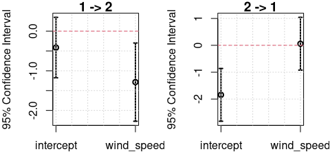

95% confidence interval of the coefficient estimes shows that only the `wind_speed` is significant when transitioning from state 1 to state 1 or 2

```r
hmm_plot_CI(ch1_hmm_windspeed)
```

The wind speed only affects the probabilities from the resting state. Animals that are resting are more likely to stay resting when the wind is high, and likewise less likely to start moving when the wind is high. However it is interesting that there is no significant (or even suggestive) effect of wind speed on animals that are already moving. That may speak to the pre-eminence of their motivation to be moving (e.g. hunger, looking for food etc) despite conditions.

# 4 Best model

```r
print(ch1_hmm_windspeed)
```

```
## Value of the maximum log-likelihood: -477.7144
##
## Step length parameters:
## ----------------------
##         state 1   state 2
## mean 0.05961488 0.3859205
## sd   0.09799240 0.2971999
##
## Turning angle parameters:
## ------------------------
##                    state 1   state 2
## mean          0.000000e+00 0.0000000
## concentration 1.397111e-08 0.9691988
##
## Regression coeffs for the transition probabilities:
## --------------------------------------------------
##                1 -> 2      2 -> 1
## intercept  -0.4156253 -1.84277685
## wind_speed -1.2858882  0.05902679
##
## Initial distribution:
## --------------------
## [1] 2.37909e-10 1.00000e+00
```

## 4.1 Model plot

Histogram of step lengths with fitted distributions (top-left), histogram of turning angles with fitted distributions (top-right), transition probabilities as functions of wind_speed (bottom-left), and map of decoded track for the cheetah (bottom-right) are shown below:

```
## Decoding states sequence... DONE
```

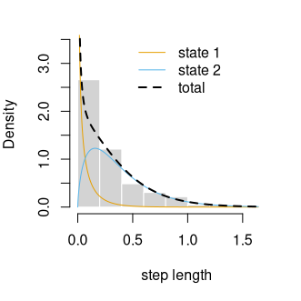

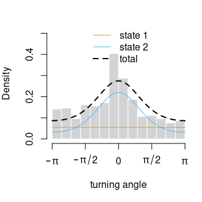

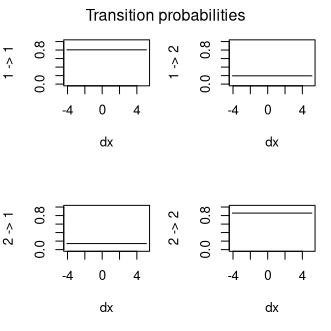

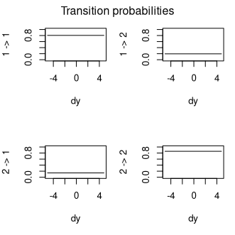

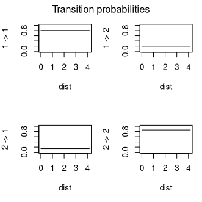

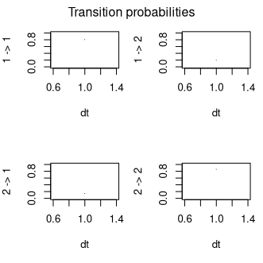

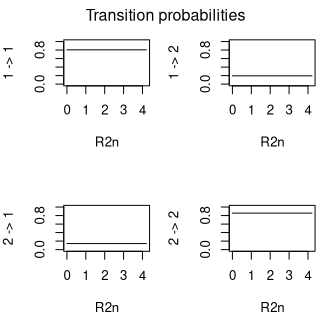

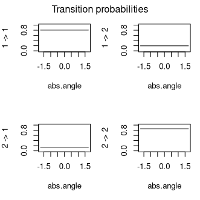

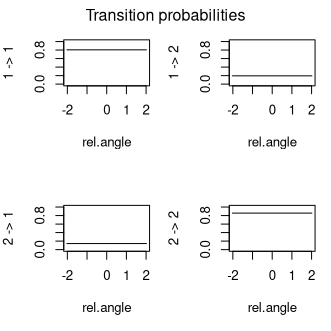

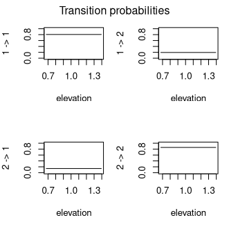

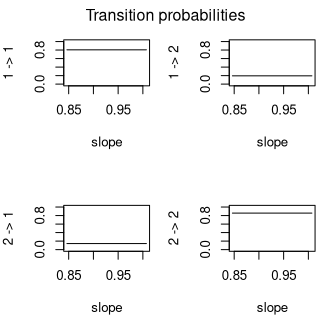

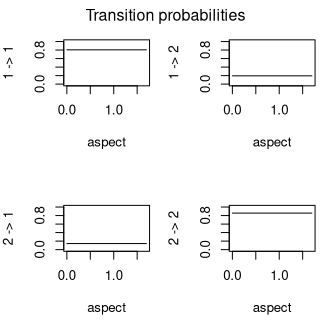

[11 more figures not shown]

```r
plot(ch1_hmm_windspeed, ask=FALSE)
```

## 4.2 States plot

In the following illustration the estimated probability of being in each state is shown. The actual states (1,2) could be computed using two approaches:

1. Viterbi: Reconstructs the most probable states sequence, using the Viterbi algorithm (Zucchini and MacDonald 2009). The result of Viterbi is shown in the top row of the following illustration.
2. Conditional statement: In this method, if the probability of being in state 1 is more than a threshold i.e. 0.5, then the animal is in state 1.

```
## Decoding states sequence... DONE
## Computing states probabilities... DONE
```

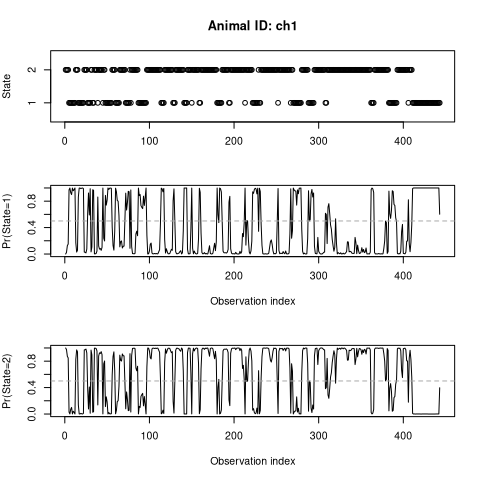

Decoded states sequence (top row), and state probabilities of observations (middle and bottom rows)

```r
# states
moveHMM::plotStates(ch1_hmm_windspeed, ask=FALSE)
```

# Reference

Cheraghi, Faridedin, Mahmoud Reza Delavar, Farshad Amiraslani, Kazem Alavipanah, Eliezer Gurarie, and William F. Fagan. 2017. “Statistical Analysis of Asiatic Cheetah Movement and Its Spatio-Temporal Drivers.” *Journal of Arid Environments*.

James, Gareth, Daniela Witten, Trevor Hastie, and Robert Tibshirani. 2013. *An Introduction to Statistical Learning: With Applications in r*. 1st ed. 2013, Corr. 6th printing 2016 edition. Springer.

Langrock, Roland, Ruth King, Jason Matthiopoulos, Len Thomas, Daniel Fortin, and Juan M. Morales. 2012. “Flexible and Practical Modeling of Animal Telemetry Data: Hidden Markov Models and Extensions.” *Ecology* 93 (11): 2336–42. https://doi.org/10.1890/11-2241.1.

Patterson, Toby A., Marinelle Basson, Mark V. Bravington, and John S. Gunn. 2009. “Classifying Movement Behaviour in Relation to Environmental Conditions Using Hidden Markov Models.” *Journal of Animal Ecology* 78 (6): 1113–23. https://doi.org/10.1111/j.1365-2656.2009.01583.x.

Zucchini, Walter, and Iain L. MacDonald. 2009. *Hidden Markov Models for Time Series: An Introduction Using r*. CRC Press.